# Busqueda por Costo

A continuacion se ejemplifica la busqueda por costo revisada en clase. Para ello se tiene un ejemplo de las ciudades del territorio Ecuatoriano y su distancia.

```python
# Busqueda por costo.

# Creamos la clase Nodo
class Node:
    def __init__(self, data, child=None): # Constructor de la clase
        self.data = data
        self.child = None
        self.fathr = None
        self.cost = None # Importante tener el costo de recorer el nodo
        self.set_child(child)

    def set_child(self, child): # Agregar hijos
        self.child = child
        if self.child is not None:
            for ch in self.child:
                ch.fathr = self

    def equal(self, node):
        if self.data == node.data:
            return True
        else:
            return False

    def on_list(self, node_list): # Verfiicar su el nodo esta en la lista
        listed = False
        for n in node_list:
            if self.equal(n):
                listed = True
        return listed

    def __str__(self): # Igual al toString Java
        return str(self.data)
```

```python
# Implementacion del metodo de busqueda por costo
def search_costo_solucion(connections, init_state, solution):
    solved = False # Variable para almacenar el estado de la busqueda
    visited_nodes = [] # Nodos visitados
    frontier_nodes = [] # Nodos en busqueda o lista nodos o nodos por visitar

    init_node = Node(init_state) # Nodo inicial
    init_node.cost =0 # Agregar costo inicial
    frontier_nodes.append(init_node)
    while (not solved) and len(frontier_nodes) != 0:
        frontier_nodes = sorted(frontier_nodes, key=Compare) # Ordenar lista de nodos
        node = frontier_nodes[0]
        visited_nodes.append(frontier_nodes.pop(0)) # Extraer nodo y añadirlo a visitados
        if node.data == solution:# Solucion encontrada
            solved = True
            return node
        else:
            node_data = node.data# Expandir nodos hijo (ciudades con conexion)
            child_list = []
            for achild in connections[node_data]: # Recorrera cada uno de los nodos hijos
                child = Node(achild)
                cost = connections[node_data][achild] # Obtener el costo del nodo
                child.cost = node.cost + cost # Agregamos el costo actual del nodo + el historial
                child_list.append(child)
                if not child.on_list(visited_nodes):
                    if child.on_list(frontier_nodes): # Si está en la lista lo sustituimos con el nuevo valor de coste si es menor
                        for n in frontier_nodes:
                            if n.equal(child) and n.cost > child.cost:
                                frontier_nodes.remove(n)
                                frontier_nodes.append(child)
                    else:
                        frontier_nodes.append(child)
            node.set_child(child_list)

if __name__ == "__main__":
    connections = {
     'Cuenca': {'Riobamba':190, 'Quito':280, 'Guayaquil':170},
        'Latacunga': {'Ambato':50, 'Quito':30},
        'Esmeraldas': {'Manta':80},
        'Manta': {'Guayaquil':60},
        'Quito': {'Riobamba':110, 'Latacunga':30, 'Cuenca':280, 'Guayaquil':190, 'Puyo':170},
        'Riobamba': {'Cuenca':190, 'Quito':110},
        'Ambato': {'Latacunga':50, 'Puyo':80, 'Guayaquil':230},
        'Puyo': {'Ambato':60, 'Quito':170},
        'Machala': {'Guayaquil':80},
        'Guayaquil': {'Machala':80, 'Ambato':230, 'Quito':190, 'Cuenca':170, 'Manta':60}





    }

    init_state = 'Latacunga'
    solution = 'Machala'
    solution_node = search_costo_solucion(connections, init_state, solution)
    # mostrar resultado
    result = []
    node = solution_node
    if node is not None:
        while node.fathr is not None:
            result.append(node.data)
            node = node.fathr
        result.append(init_state)
        result.reverse() # Reverso el resultado (Solo para presentar)
        print(result)
        print("Costo total: %s" % str(solution_node.cost)) # Imprimir el costo total de llegar al nodo
    else:
        print("No hay solucion !!!!")
```

```
['Latacunga', 'Quito', 'Guayaquil', 'Machala']
Costo total: 300
```

# Grafico

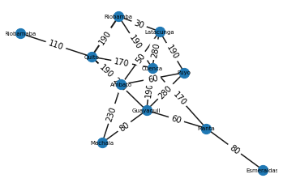

```python
import os, sys

#Grafo no ponderado

import networkx as nx
import matplotlib.pyplot as plt
GL = nx.Graph()
GL.add_edge('Riobamba','Quito', weight = 2, label = '190')
GL.add_edge('Quito','Guayaquil', weight = 1.5, label = '280')
GL.add_edge('Ambato','Quito', weight = 1.5, label = '50')
GL.add_edge('Quito','Ambato', weight = 1.5, label = '30')
GL.add_edge('Esmeraldas','Manta', weight = 1.5, label = '80')
GL.add_edge('Manta','Guayaquil', weight = 1.5, label = '60')
GL.add_edge('Quito','Riobamaba', weight = 1.5, label = '110')
GL.add_edge('Riobamba','Latacunga', weight = 1.5, label = '30')
GL.add_edge('Cuenca','Latacunga', weight = 1.5, label = '280')
GL.add_edge('Cuenca','Guayaquil', weight = 1.5, label = '190')
GL.add_edge('Guayaquil','Puyo', weight = 1.5, label = '170')
GL.add_edge('Cuenca','Latacunga', weight = 1.5, label = '280')
GL.add_edge('Guayaquil','Puyo', weight = 1.5, label = '170')
GL.add_edge('Riobamba','Cuenca', weight = 1.5, label = '190')
GL.add_edge('Cuenca','Quito', weight = 1.5, label = '110')
GL.add_edge('Ambato','Latacunga', weight = 1.5, label = '50')
GL.add_edge('Latacunga','Puyo', weight = 1.5, label = '190')
GL.add_edge('Guayaquil','Puyo', weight = 1.5, label = '170')
GL.add_edge('Puyo','Guayaquil', weight = 1.5, label = '280')
GL.add_edge('Puyo','Ambato', weight = 1.5, label = '60')
GL.add_edge('Ambato','Quito', weight = 1.5, label = '170')
GL.add_edge('Machala','Guayaquil', weight = 1.5, label = '80')
GL.add_edge('Guayaquil','Machala', weight = 1.5, label = '80')
GL.add_edge('Machala','Ambato', weight = 1.5, label = '230')
GL.add_edge('Ambato','Quito', weight = 1.5, label = '190')
GL.add_edge('Quito','Cuenca', weight = 1.5, label = '170')
GL.add_edge('Cuenca','Manta', weight = 1.5, label = '170')


weights = [GL[u][v]['weight'] for u,v in GL.edges()]
etiquetas = [GL[u][v]['label'] for u,v in GL.edges()]
pos =nx.spring_layout(GL)
nx.draw_networkx_nodes(GL, pos, node_size=150) #nodos
nx.draw_networkx_edges(GL, pos, width=weights, alpha=0.9, edge_color='black')
nx.draw_networkx_edge_labels(GL,pos,edge_labels={(u,v):GL[u][v]['label'] for u,v in
GL.edges()} ,font_color='black')
nx.draw_networkx_labels(GL, pos, font_size=7, font_family='sans-serif')
plt.axis('off')
plt.show()
```

## Practica

Implementar un algoritmo que me permita dibujar las conexiones con los costos y los resultados del grafo.

Mediante el uso de la herramienta de Google Maps tomar al su direccion domiciliaria como punto de partida y generar un arbol jerarquico con todos los posibles Policia/UPC/Funcion Judicial, para ello se debe tener como primer nivel los mas cercanos y a continuacion los demas generando un arbol jerarquico.

Realizar los calculos para obtener el factor de ramificacion, análisis del algoritmo en términos de completitud, optimalidad, complejidad temporal y complejidad espacial.

Subir el cuaderno con la resolucion

Generar un arbol de expansion del COVID-19 en el Ecuador y agregarle al metodo de costo para obtener la ruta de contagio.

```python
# Busqueda por costo.
# Busqueda por costo UPC POLICIAS
# Creamos la clase Nodo
class Node:
    def __init__(self, data, child=None): # Constructor de la clase
        self.data = data
        self.child = None
        self.fathr = None
        self.cost = None # Importante tener el costo de recorer el nodo
        self.set_child(child)

    def set_child(self, child): # Agregar hijos
        self.child = child
        if self.child is not None:
            for ch in self.child:
                ch.fathr = self

    def equal(self, node):
        if self.data == node.data:
            return True
        else:
            return False

    def on_list(self, node_list): # Verfiicar su el nodo esta en la lista
        listed = False
        for n in node_list:
            if self.equal(n):
                listed = True
        return listed

    def __str__(self): # Igual al toString Java
        return str(self.data)
```

```python
# Implementacion del metodo de busqueda por costo
def search_costo_solucion(connections, init_state, solution):
    solved = False # Variable para almacenar el estado de la busqueda
    visited_nodes = [] # Nodos visitados
    frontier_nodes = [] # Nodos en busqueda o lista nodos o nodos por visitar

    init_node = Node(init_state) # Nodo inicial
    init_node.cost =0 # Agregar costo inicial
    frontier_nodes.append(init_node)
    while (not solved) and len(frontier_nodes) != 0:
        frontier_nodes = sorted(frontier_nodes, key=Compare) # Ordenar lista de nodos
        node = frontier_nodes[0]
        visited_nodes.append(frontier_nodes.pop(0)) # Extraer nodo y añadirlo a visitados
        if node.data == solution:# Solucion encontrada
            solved = True
            return node
        else:
            node_data = node.data# Expandir nodos hijo (ciudades con conexion)
            child_list = []
            for achild in connections[node_data]: # Recorrera cada uno de los nodos hijos
                child = Node(achild)
                cost = connections[node_data][achild] # Obtener el costo del nodo
                child.cost = node.cost + cost # Agregamos el costo actual del nodo + el historial
                child_list.append(child)
                if not child.on_list(visited_nodes):
                    if child.on_list(frontier_nodes): # Si está en la lista lo sustituimos con el nuevo valor de coste si es menor
                        for n in frontier_nodes:
                            if n.equal(child) and n.cost > child.cost:
                                frontier_nodes.remove(n)
                                frontier_nodes.append(child)
                    else:
                        frontier_nodes.append(child)
            node.set_child(child_list)

if __name__ == "__main__":
    connections = {
       'UPC Tarqui': {'UPC Victoria':190, 'UPC Salado':20, 'UPC  Vergel':120},
        'UPC Americas': {'UPC Batan':60, 'UPC Salado':70},
        'UPC Ordoñez Lasso': {'UPC Cayamabe':40},
        'UPC Cayamabe': {'UPC  Vergel':60},
        'UPC Salado': {'UPC Victoria':160, 'UPC Americas':20, 'UPC Tarqui':230, 'UPC  Vergel':190, 'UPC Paraiso':170},
        'UPC Victoria': {'UPC Tarqui':190, 'UPC Salado':110},
        'UPC Batan': {'UPC Americas':50, 'UPC Paraiso':80, 'UPC  Vergel':230},
        'UPC Paraiso': {'UPC Batan':4, 'UPC Salado':170},
        'UPC Terminal': {'UPC  Vergel':80},
        'UPC  Vergel': {'UPC Terminal':80, 'UPC Batan':230, 'UPC Salado':190, 'UPC Tarqui':170, 'UPC Cayamabe':60}


    }

    init_state = 'UPC Americas'
    solution = 'UPC Terminal'
    solution_node = search_costo_solucion(connections, init_state, solution)
    # mostrar resultado
    result = []
    node = solution_node
    if node is not None:
        while node.fathr is not None:
            result.append(node.data)
            node = node.fathr
        result.append(init_state)
        result.reverse() # Reverso el resultado (Solo para presentar)
        print(result)
        print("Costo total: %s" % str(solution_node.cost)) # Imprimir el costo total de llegar al nodo
    else:
        print("No hay solucion !!!!")
```

[output not shown]

# *n= 11*

*d= 5*

*Calculo*

\begin{equation*} Fr = \frac{n}{d} \end{equation*}\begin{equation*} Fr = \frac{11}{5}{= 2,2} \end{equation*}

# COVID

Generar un arbol de expansion del COVID-19 en el Ecuador y agregarle al metodo de costo para obtener la ruta de contagio

```python
# Busqueda por costo.

# Creamos la clase Nodo
class Node:
    def __init__(self, data, child=None):  # Constructor de la clase
        self.data = data
        self.child = None
        self.fathr = None
        self.cost = None  # Importante tener el costo de recorer el nodo
        self.set_child(child)

    def set_child(self, child):  # Agregar hijos
        self.child = child
        if self.child is not None:
            for ch in self.child:
                ch.fathr = self

    def equal(self, node):
        if self.data == node.data:
            return True
        else:
            return False

    def on_list(self, node_list):  # Verfiicar su el nodo esta en la lista
        listed = False
        for n in node_list:
            if self.equal(n):
                listed = True
        return listed

    def __str__(self):  # Igual al toString Java
        return str(self.data)
```

```python
def search_costo_solucion(connections, init_state, solution):
    solved = False  # Variable para almacenar el estado de la busqueda
    visited_nodes = []  # Nodos visitados
    frontier_nodes = []  # Nodos en busqueda o lista nodos o nodos por visitar

    init_node = Node(init_state)  # Nodo inicial
    init_node.cost = 0  # Agregar costo inicial
    frontier_nodes.append(init_node)
    while (not solved) and len(frontier_nodes) != 0:
        frontier_nodes = sorted(frontier_nodes, key=Compare)  # Ordenar lista de nodos
        node = frontier_nodes[0]
        visited_nodes.append(frontier_nodes.pop(0))  # Extraer nodo y añadirlo a visitados
        if node.data == solution:  # Solucion encontrada
            solved = True
            return node
        else:
            node_data = node.data  # Expandir nodos hijo (ciudades con conexion)
            child_list = []
            for achild in connections[node_data]:  # Recorrera cada uno de los nodos hijos
                child = Node(achild)
                cost = connections[node_data][achild]  # Obtener el costo del nodo
                child.cost = node.cost + cost  # Agregamos el costo actual del nodo + el historial
                child_list.append(child)
                if not child.on_list(visited_nodes):
                    if child.on_list(
                            frontier_nodes):  # Si está en la lista lo sustituimos con el nuevo valor de coste si es menor
                        for n in frontier_nodes:
                            if n.equal(child) and n.cost > child.cost:
                                frontier_nodes.remove(n)
                                frontier_nodes.append(child)
                    else:
                        frontier_nodes.append(child)
            node.set_child(child_list)


if __name__ == "__main__":
    connections = {
      'Ecuador': {'Guayas':5551, 'Pichincha':674, 'Los Rios':227},
        'Azuay': {'El Oro':183, 'Pichincha':674},
        'Cañar': {'Santa Elena':92},
        'Santa Elena': {'Chimborazo':90},
        'Pichincha': {'Guayas':5551, 'Azuay':200, 'Loja':85},
        'Guayas': {'Azuay':200, 'Pichinhca':674},
        'El Oro': {'Azuay':200, 'Loja':85, 'Guayas':5551},
        'Guayas': {'El Oro':183, 'Pichincha':674},
        'Santo Domingo': {'Guayas':5551},
        'Guayas': {'Santo Domingo':67, 'El Oro':183, 'Pichincha':674, 'Azuay':200, 'Santa Elena':92}

    }

    init_state = 'Guayas'
    solution = 'Azua'
    solution_node = search_costo_solucion(connections, init_state, solution)
    # mostrar resultado
    result = []
    node = solution_node
    if node is not None:
        while node.fathr is not None:
            result.append(node.data)
            node = node.fathr
        result.append(init_state)
        result.reverse()  # Reverso el resultado (Solo para presentar)
        print(result)
        print("Costo total: %s" % str(solution_node.cost))  # Imprimir el costo total de llegar al nodo
    else:
        print("No hay solucion !!!!")
```

[output not shown]

# Grafico Covid

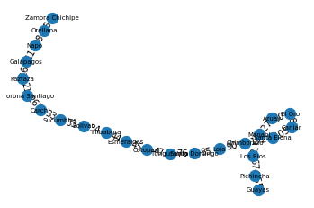

```python
import os, sys

#Grafo no ponderado

import networkx as nx
import matplotlib.pyplot as plt
GL = nx.Graph()
GL.add_edge('Guayas','Pichincha', weight = 2, label = '5551')
GL.add_edge('Pichincha','Los Rios', weight = 1.5, label = '674')
GL.add_edge('Los Rios','Manabi', weight = 1.5, label = '255')
GL.add_edge('Manabi','Azuay', weight = 1.5, label = '227')
GL.add_edge('Azuay','El Oro', weight = 1.5, label = '200')
GL.add_edge('El Oro','Caniar', weight = 1.5, label = '183')
GL.add_edge('Caniar','Santa Elena', weight = 1.5, label = '105')
GL.add_edge('Santa Elena','Chimborazo', weight = 1.5, label = '192')
GL.add_edge('Santa Elena','Chimborazo', weight = 1.5, label = '192')
GL.add_edge('Chimborazo','Loja', weight = 1.5, label = '90')
GL.add_edge('Loja','Santo Domingo', weight = 1.5, label = '85')
GL.add_edge('Santo Domingo','Tungurahua', weight = 1.5, label = '76')
GL.add_edge('Tungurahua','Cotopaxi', weight = 1.5, label = '47')
GL.add_edge('Cotopaxi','Esmeraldas', weight = 1.5, label = '45')
GL.add_edge('Esmeraldas','Imbabura', weight = 1.5, label = '44')
GL.add_edge('Imbabura','Bolivar', weight = 1.5, label = '34')
GL.add_edge('Bolivar','Sucumbios', weight = 1.5, label = '33')
GL.add_edge('Sucumbios','Carchi', weight = 1.5, label = '33')
GL.add_edge('Carchi','Morona Santiago', weight = 1.5, label = '261')
GL.add_edge('Morona Santiago','Paztaza', weight = 1.5, label = '21')
GL.add_edge('Paztaza','Galapagos', weight = 1.5, label = '16')
GL.add_edge('Galapagos','Napo', weight = 1.5, label = '11')
GL.add_edge('Napo','Orellana', weight = 1.5, label = '8')
GL.add_edge('Orellana','Zamora Chichipe', weight = 1.5, label = '5')
weights = [GL[u][v]['weight'] for u,v in GL.edges()]
etiquetas = [GL[u][v]['label'] for u,v in GL.edges()]
pos =nx.spring_layout(GL)
nx.draw_networkx_nodes(GL, pos, node_size=150) #nodos
nx.draw_networkx_edges(GL, pos, width=weights, alpha=0.9, edge_color='black')
nx.draw_networkx_edge_labels(GL,pos,edge_labels={(u,v):GL[u][v]['label'] for u,v in
GL.edges()} ,font_color='black')
nx.draw_networkx_labels(GL, pos, font_size=7, font_family='sans-serif')
plt.axis('off')
plt.show()
```